# dplyr

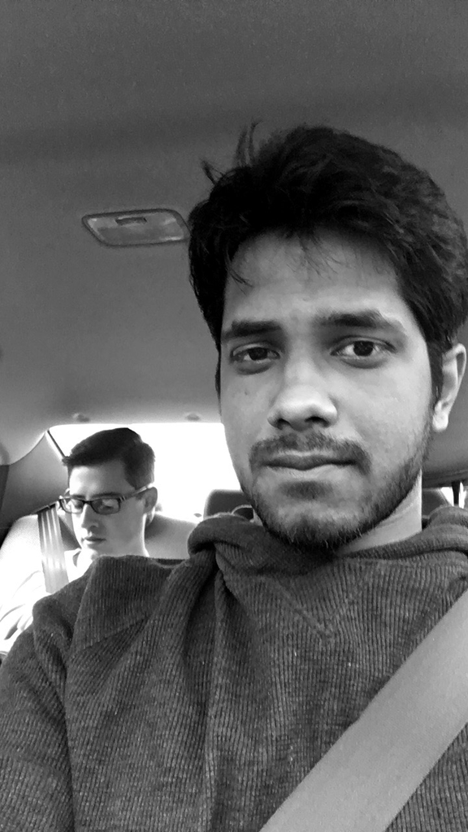

#### My name is Akhilesh Atluri, I am an Graduate student majoring in Data Science at Mercyhurst University

## Filtering Columns and Rows.

when using dplyr, you can filter columns and rows by using select and filter. Let’s look at an example using the Lahman baseball databse. we first have to load the Lahmna and dplyr packages

## The packages required to run the code

```r
library(Lahman)
library(dplyr)
```

## Selecting a particular Column in the dataframe

now , suppose we would like to see the homerun totals for the 1927 new york yankees. we could run the following code

```r
Batting%>%
  select(playerID,yearID,teamID,HR)%>%
filter(teamID=="NYA" & yearID==1927)
```

```
##     playerID yearID teamID HR
## 1  beallwa01   1927    NYA  0
## 2  bengobe01   1927    NYA  0
## 3  collipa01   1927    NYA  7
## 4  combsea01   1927    NYA  6
## 5  duganjo01   1927    NYA  2
## 6  durstce01   1927    NYA  0
## 7  gazelmi01   1927    NYA  0
## 8  gehrilo01   1927    NYA 47
## 9  giardjo01   1927    NYA  0
## 10 grabojo01   1927    NYA  0
## 11  hoytwa01   1927    NYA  0
## 12 koenima01   1927    NYA  3
## 13 lazzeto01   1927    NYA 18
## 14 meusebo01   1927    NYA  8
## 15 moorewi01   1927    NYA  1
## 16 morehra01   1927    NYA  1
## 17 paschbe01   1927    NYA  2
## 18 pennohe01   1927    NYA  0
## 19 pipgrge01   1927    NYA  1
## 20 ruethdu01   1927    NYA  1
## 21  ruthba01   1927    NYA 60
## 22 shawkbo01   1927    NYA  0
## 23 shockur01   1927    NYA  0
## 24 thomamy01   1927    NYA  0
## 25  weraju01   1927    NYA  1
```

## Arranging a Column in Descending Order

Now,the following code gives the list of all the players that have scored more than 40 homeruns from New York Yankees Team.

```r
Batting%>%
  select(playerID,yearID,teamID,HR,SO,AB)%>%
  filter(teamID == "NYA" & HR > 40)%>%
  arrange(desc(HR))
```

```
##     playerID yearID teamID HR  SO  AB
## 1  marisro01   1961    NYA 61  67 590
## 2   ruthba01   1927    NYA 60  89 540
## 3   ruthba01   1921    NYA 59  81 540
## 4   ruthba01   1920    NYA 54  80 457
## 5   ruthba01   1928    NYA 54  87 536
## 6  mantlmi01   1961    NYA 54 112 514
## 7  rodrial01   2007    NYA 54 120 583
## 8  mantlmi01   1956    NYA 52  99 533
## 9   ruthba01   1930    NYA 49  61 518
## 10 gehrilo01   1934    NYA 49  31 579
## 11 gehrilo01   1936    NYA 49  46 579
## 12 rodrial01   2005    NYA 48 139 605
## 13  ruthba01   1926    NYA 47  76 495
## 14 gehrilo01   1927    NYA 47  84 584
## 15  ruthba01   1924    NYA 46  81 529
## 16  ruthba01   1929    NYA 46  60 499
## 17 gehrilo01   1931    NYA 46  56 619
## 18  ruthba01   1931    NYA 46  51 534
## 19 dimagjo01   1937    NYA 46  37 621
## 20 martiti02   1997    NYA 44  75 594
## 21 grandcu01   2012    NYA 43 195 596
## 22 mantlmi01   1958    NYA 42 120 519
## 23  ruthba01   1923    NYA 41  93 522
## 24 gehrilo01   1930    NYA 41  63 581
## 25  ruthba01   1932    NYA 41  62 457
## 26 jacksre01   1980    NYA 41 122 514
## 27 giambja01   2002    NYA 41 112 560
## 28 giambja01   2003    NYA 41 140 535
## 29 grandcu01   2011    NYA 41 169 583
```

Next let’s find all the players from the data who has scored over 40 homeruns but have less than 60 strikeouts.

## Filtering rows depending on the statistics

```r
Batting%>%
  select(playerID,yearID,teamID,HR,SO)%>%
  filter(SO < 60 ,HR >= 40)%>%
  arrange(desc(HR))
```

```
##     playerID yearID teamID HR SO
## 1   mizejo01   1947    NY1 51 42
## 2  gehrilo01   1934    NYA 49 31
## 3  gehrilo01   1936    NYA 49 46
## 4  kluszte01   1954    CIN 49 35
## 5  pujolal01   2006    SLN 49 50
## 6  kluszte01   1955    CIN 47 40
## 7  aaronha01   1971    ATL 47 58
## 8  gehrilo01   1931    NYA 46 56
## 9   ruthba01   1931    NYA 46 51
## 10 dimagjo01   1937    NYA 46 37
## 11 bondsba01   2002    SFN 46 47
## 12 pujolal01   2004    SLN 46 52
## 13 bondsba01   2003    SFN 45 58
## 14 bondsba01   2004    SFN 45 41
```

[output cut: 18 more lines]

If we want to see players with more than 30 homeruns scored from Phillies in 1970’s we can use the following code.

```r
Batting%>%
  select(playerID,yearID,teamID,HR,SO,AB)%>%
  filter(teamID == "PHI" & HR > 30 & yearID >=1970 & yearID <= 1979)%>%
  arrange(desc(HR))
```

```
##    playerID yearID teamID HR  SO  AB
## 1 schmimi01   1979    PHI 45 115 541
## 2 luzingr01   1977    PHI 39 140 554
## 3 schmimi01   1975    PHI 38 180 562
## 4 schmimi01   1976    PHI 38 149 584
## 5 schmimi01   1977    PHI 38 122 544
## 6 schmimi01   1974    PHI 36 138 568
## 7 luzingr01   1978    PHI 35 135 540
## 8 johnsde01   1971    PHI 34 146 582
## 9 luzingr01   1975    PHI 34 151 596
```

Lets see the list of all the players who have hit more than 50 homeruns and also sort them in descending order.

```r
Batting%>%
  select(playerID,yearID,teamID,HR,SO, AB)%>%
  filter(HR>50)%>%
  arrange(desc(HR))
```

```
##     playerID yearID teamID HR  SO  AB
## 1  bondsba01   2001    SFN 73  93 476
## 2  mcgwima01   1998    SLN 70 155 509
## 3   sosasa01   1998    CHN 66 171 643
## 4  mcgwima01   1999    SLN 65 141 521
## 5   sosasa01   2001    CHN 64 153 577
## 6   sosasa01   1999    CHN 63 171 625
## 7  marisro01   1961    NYA 61  67 590
## 8   ruthba01   1927    NYA 60  89 540
## 9   ruthba01   1921    NYA 59  81 540
## 10  foxxji01   1932    PHA 58  96 585
## 11 greenha01   1938    DET 58  92 556
## 12 howarry01   2006    PHI 58 181 581
## 13 gonzalu01   2001    ARI 57  83 609
## 14 rodrial01   2002    TEX 57 122 624
```

[output cut: 22 more lines]

Lets now see all the players who have less than 10 strikeouts but have more than 400 at bats

```r
Batting%>%
  select(playerID,yearID,teamID,HR,SO, AB)%>%
  filter(SO < 10 & AB > 400)%>%
  arrange(SO)
```

```
##     playerID yearID teamID HR SO  AB
## 1  doyleja01   1894    NY1  3  3 422
## 2  seweljo01   1932    NYA 11  3 503
## 3  seweljo01   1925    CLE  1  4 608
## 4  seweljo01   1929    CLE  7  4 578
## 5  seweljo01   1933    NYA  2  4 524
## 6   wardjo01   1893    NY1  2  5 588
## 7  holloch01   1922    CHN  3  5 592
## 8  mcinnst01   1922    CLE  1  5 537
## 9  wanerll01   1936    PIT  1  5 414
## 10 wrighge01   1875    BS1  2  6 408
## 11 broutda01   1889    BSN  7  6 485
## 12 keelewi01   1894    BLN  5  6 590
## 13  wardjo01   1894    NY1  0  6 540
## 14 quinnjo02   1895    SLN  2  6 543
```

[output cut: 51 more lines]

## Summarizing and creating a new column

Lets calculate all the homeruns scored by Babe Ruth

```r
Batting%>%
  filter(playerID=='ruthba01')%>%
  group_by(playerID)%>%
  summarize(career_HR=sum(HR))
```

```
## # A tibble: 1 x 2
##   playerID career_HR
##      <chr>     <int>
## 1 ruthba01       714
```

Lets find all the players having more than 600 homeruns with the higest on top of the table

```r
 Batting%>%
  group_by(playerID)%>%
  summarize(career_HR=sum(HR))%>%
  filter(career_HR>=600)%>%
  arrange(desc(career_HR))
```

```
## # A tibble: 8 x 2
##    playerID career_HR
##       <chr>     <int>
## 1 bondsba01       762
## 2 aaronha01       755
## 3  ruthba01       714
## 4 rodrial01       696
## 5  mayswi01       660
## 6 griffke02       630
## 7 thomeji01       612
## 8  sosasa01       609
```

Now lets look at the average homeruns of players who have average more than 30

```r
 Batting%>%
  group_by(playerID)%>%
  summarize(HRAvg=mean(HR))%>%
  filter(HRAvg>30)%>%
  arrange(desc(HRAvg))
```

```
## # A tibble: 13 x 2
##     playerID    HRAvg
##        <chr>    <dbl>
##  1 pujolal01 36.93750
##  2 bondsba01 34.63636
##  3 mcgwima01 34.29412
##  4 kinerra01 33.54545
##  5 aaronha01 32.82609
##  6 bryankr01 32.50000
##  7  ruthba01 32.45455
##  8  sosasa01 32.05263
##  9 cabremi01 31.85714
## 10 belleal01 31.75000
## 11 rodrial01 31.63636
## 12 schmimi01 30.44444
## 13 abreujo02 30.33333
```

Lets see players who have hit more than 50 homeruns in a year since 1970

```r
Batting%>%
  filter(yearID>=1970)%>%
  group_by(playerID)%>%
  summarize(max_HR=max(HR))%>%
  filter(max_HR>50)%>%
  arrange(desc(max_HR))
```

```
## # A tibble: 14 x 2
##     playerID max_HR
##        <chr>  <dbl>
##  1 bondsba01     73
##  2 mcgwima01     70
##  3  sosasa01     66
##  4 howarry01     58
##  5 gonzalu01     57
##  6 rodrial01     57
##  7 griffke02     56
##  8 bautijo02     54
##  9 ortizda01     54
## 10 davisch02     53
## 11 fostege01     52
## 12 thomeji01     52
## 13 fieldce01     51
## 14 jonesan01     51
```